# wrangle_act

**To get additional data, use the tweet IDs in the WeRateDogs Twitter archive, query the Twitter API for each tweet's JSON data using Python's Tweepy library and store each tweet's entire set of JSON data in a file called tweet_json.txt file**

```python
import pandas as pd
import numpy as np
import tweepy
import json
```

```python
# Read the twitter-archive-enhanced.csv file to get the tweet_id list
twitter_archive = pd.read_csv("twitter-archive-enhanced.csv", sep="," )
```

```python
# Use the developer account for authentication
consumer_key = '.....'
consumer_secret = '....'
access_token = '.....'
access_secret = '....'

# Initialize an OAuthHandler instance
auth = tweepy.OAuthHandler(consumer_key, consumer_secret)
# Access to the Twitter API
auth.set_access_token(access_token, access_secret)
# Create an API
api = tweepy.API(auth, wait_on_rate_limit=True, wait_on_rate_limit_notify=True)
```

```python
# Read
list_tweet_ids = twitter_archive['tweet_id'].tolist()
list_tweet_ids[0]
```

```
892420643555336193
```

```python
# download tweets by list of tweet_id
list_of_tweets = []
list_of_tweets_not_found = [] # list of tweets not found

#start = time.time() # verify the time

for id in list_tweet_ids:
    try:
        list_of_tweets.append(api.get_status(id))
    except Exception as e:
        list_of_tweets_not_found.append(id)

#end = time.time()
#print(end - start)
```

```python
len(list_of_tweets)
```

```
877
```

```python
# Save the json content of each tweets in list_of_tweets to tweet_json.txt
list_of_tweets_json = []
for tweet in list_of_tweets:
    list_of_tweets_json.append(tweet._json)

with open('tweet_json.txt', 'w') as file:
        file.write(json.dumps(list_of_tweets_json, indent=4))
```

**- Split some data might be interesting in further analyses**

```python
features = []
with open('tweet_json.txt', encoding='utf-8') as json_file:
    all_data = json.load(json_file)
    for data in all_data:
        tweet_id = data['id']
        text = data['text']
        url = text[text.find('https'):]
        favorite_count = data['favorite_count']
        retweet_count = data['retweet_count']
        created_at = data['created_at']
        source = data['source']
        only_device = source[source.find('rel="nofollow">') + 15:-4]
        source = only_device
        retweeted_status = data['retweeted_status'] = data.get('retweeted_status', 'Original tweet')
        if retweeted_status != 'Original tweet':
            retweeted_status = 'This is a retweet'
            url = 'This is a retweet'

        features.append({'tweet_id': str(tweet_id),
                             'favorite_count': int(favorite_count),
                             'retweet_count': int(retweet_count),
                             'url': url,
                             'created_at': created_at,
                             'source': source,
                             'retweeted_status': retweeted_status,
                            })
        additional_features = pd.DataFrame(features,
        columns = ['tweet_id', 'favorite_count',
                   'retweet_count', 'created_at',
                   'source', 'retweeted_status', 'url'])
```

```python
# save to local file for reuse later
additional_features.to_csv("additional_features.csv", index = False)
```

**Because of limit rate to download from Twitter_API, I will save downloaded tweets to a additional_features.csv but will use the given "tweet-json.txt" for analyses**

```python
# Read data from the provides tweet-json.txt file and split interesting features**
features2 = []

with open('tweet-json.txt') as file:
    for li in file:
        line = json.loads(li)
        tw_id = line['id']
        full_text = line['full_text']
        url = full_text[full_text.find('https'):]
        favorite_count = line['favorite_count']
        retweet_count = line['retweet_count']
        created_at = line['created_at']
        source = line['source']
        only_device = source[source.find('rel="nofollow">') + 15:-4]
        source = only_device
        retweeted_status = line['retweeted_status'] = line.get('retweeted_status', 'Original tweet')
        if retweeted_status != 'Original tweet':
            retweeted_status = 'This is a retweet'
            url = 'This is a retweet'

        features2.append({'tweet_id': str(tw_id),
                             'favorite_count': int(favorite_count),
                             'retweet_count': int(retweet_count),
                             'url': url,
                             'created_at': created_at,
                             'source': source,
                             'retweeted_status': retweeted_status,
                            })
        additional_features2 = pd.DataFrame(features2,
        columns = ['tweet_id', 'favorite_count',
                   'retweet_count', 'created_at',
                   'source', 'retweeted_status', 'url'])
```

```python
# Verify
additional_features2.head(2)
```

|  | tweet_id | favorite_count | retweet_count | created_at | source | retweeted_status | url |
| --- | --- | --- | --- | --- | --- | --- | --- |
| 0 | 892420643555336193 | 39467 | 8853 | Tue Aug 01 16:23:56 +0000 2017 | Twitter for iPhone | Original tweet | https://t.co/MgUWQ76dJU |
| 1 | 892177421306343426 | 33819 | 6514 | Tue Aug 01 00:17:27 +0000 2017 | Twitter for iPhone | Original tweet | https://t.co/0Xxu71qeIV |

```python
additional_features2.to_csv("additional_features2.csv", index = False)
```

# Wrangle part

## Outline:

> Data wrangling:
> - Gathering data
>   - twitter_archive_enhanced.csv (provided)
>   - image_predictions.tsv (Request)
>   - Additional info (retweet, favourite_count, etc.): tweet_json.txt (download using tweetAPI)
> - Assessing data
> - Cleaning data
> - Storing, analyzing, and visualizing

### Gathering data

```python
# import libraries
import pandas as pd
import numpy as np
import requests
from PIL import Image
import io
import datetime as dt
import tweepy
import datetime as dt
import json
import re
import itertools
import matplotlib.pyplot as plt
import seaborn as sb
%matplotlib inline
```

**1. Gather the WeRateDogs Twitter archive file**

```python
# Read the twitter-archive-enhanced.csv file
twitter_archive = pd.read_csv("twitter-archive-enhanced.csv", sep="," )
```

```python
twitter_archive.shape
```

```
(2356, 17)
```

**2. Download the image_predictions.tsv file and save it to local file**

```python
# Download the image_predictions.tsv file
link = 'https://d17h27t6h515a5.cloudfront.net/topher/2017/August/599fd2ad_image-predictions/image-predictions.tsv'
response = requests.get(link)
response
```

```
<Response [200]>
```

```python
# Read the response.content in binary mode and save it to image_predictions.tsv
file_name = link.split('/')[-1]
with open(file_name, mode='wb') as file:
    file.write(response.content)

# Load to pandas
image_predictions = pd.read_csv(file_name, sep = '\t')
image_predictions.shape
```

```
(2075, 12)
```

**3. Load the additional_features**

```python
additional_features2 = pd.read_csv("additional_features2.csv")
```

## Assessing data

### **1. Twitter_archive dataset**

```python
twitter_archive.info()
```

```
<class 'pandas.core.frame.DataFrame'>
RangeIndex: 2356 entries, 0 to 2355
Data columns (total 17 columns):
 #   Column                      Non-Null Count  Dtype
---  ------                      --------------  -----
 0   tweet_id                    2356 non-null   int64
 1   in_reply_to_status_id       78 non-null     float64
 2   in_reply_to_user_id         78 non-null     float64
 3   timestamp                   2356 non-null   object
 4   source                      2356 non-null   object
 5   text                        2356 non-null   object
 6   retweeted_status_id         181 non-null    float64
 7   retweeted_status_user_id    181 non-null    float64
 8   retweeted_status_timestamp  181 non-null    object
 9   expanded_urls               2297 non-null   object
 10  rating_numerator            2356 non-null   int64
 11  rating_denominator          2356 non-null   int64
 12  name                        2356 non-null   object
 13  doggo                       2356 non-null   object
 14  floofer                     2356 non-null   object
 15  pupper                      2356 non-null   object
 16  puppo                       2356 non-null   object
dtypes: float64(4), int64(3), object(10)
memory usage: 313.0+ KB
```

```python
twitter_archive.isnull().sum().sort_values(ascending = False)
```

```
in_reply_to_status_id         2278
in_reply_to_user_id           2278
retweeted_status_timestamp    2175
retweeted_status_user_id      2175
retweeted_status_id           2175
expanded_urls                   59
timestamp                        0
source                           0
text                             0
puppo                            0
pupper                           0
rating_numerator                 0
rating_denominator               0
name                             0
doggo                            0
floofer                          0
tweet_id                         0
dtype: int64
```

**Issues**

> - **id colums (tweet_id, in_reply_to_status_id, in_reply_to_user_id, retweeted_status_id, retweeted_status_user_id) should be in character than float**
> - **colums with missing data:**
>   - in_reply_to_status_id, in_reply_to_user_id
>   - retweeted_status_id, retweeted_status_user_id, retweeted_status_timestamp
>   - expanded_urls
> - **timestamp and retweeted_status_timestamp should be in datetime**
> - **Tidiness: doggo, floofer, pupper, puppo should be at the same columns**

```python
# count the unique number of each columns
twitter_archive.nunique()
```

```
tweet_id                      2356
in_reply_to_status_id           77
in_reply_to_user_id             31
timestamp                     2356
source                           4
text                          2356
retweeted_status_id            181
retweeted_status_user_id        25
retweeted_status_timestamp     181
expanded_urls                 2218
rating_numerator                40
rating_denominator              18
name                           957
doggo                            2
floofer                          2
pupper                           2
puppo                            2
dtype: int64
```

```python
twitter_archive.describe()
```

|  | tweet_id | in_reply_to_status_id | in_reply_to_user_id | retweeted_status_id | retweeted_status_user_id | rating_numerator | rating_denominator |
| --- | --- | --- | --- | --- | --- | --- | --- |
| count | 2.356000e+03 | 7.800000e+01 | 7.800000e+01 | 1.810000e+02 | 1.810000e+02 | 2356.000000 | 2356.000000 |
| mean | 7.427716e+17 | 7.455079e+17 | 2.014171e+16 | 7.720400e+17 | 1.241698e+16 | 13.126486 | 10.455433 |
| std | 6.856705e+16 | 7.582492e+16 | 1.252797e+17 | 6.236928e+16 | 9.599254e+16 | 45.876648 | 6.745237 |
| min | 6.660209e+17 | 6.658147e+17 | 1.185634e+07 | 6.661041e+17 | 7.832140e+05 | 0.000000 | 0.000000 |
| 25% | 6.783989e+17 | 6.757419e+17 | 3.086374e+08 | 7.186315e+17 | 4.196984e+09 | 10.000000 | 10.000000 |
| 50% | 7.196279e+17 | 7.038708e+17 | 4.196984e+09 | 7.804657e+17 | 4.196984e+09 | 11.000000 | 10.000000 |
| 75% | 7.993373e+17 | 8.257804e+17 | 4.196984e+09 | 8.203146e+17 | 4.196984e+09 | 12.000000 | 10.000000 |
| max | 8.924206e+17 | 8.862664e+17 | 8.405479e+17 | 8.874740e+17 | 7.874618e+17 | 1776.000000 | 170.000000 |

```python
twitter_archive.name.value_counts()
```

```
None        745
a            55
Charlie      12
Lucy         11
Oliver       11
           ...
Chubbs        1
Jazz          1
Berkeley      1
Chase         1
Carper        1
Name: name, Length: 957, dtype: int64
```

```python
twitter_archive.sample(5)
```

|  | tweet_id | in_reply_to_status_id | in_reply_to_user_id | timestamp | source | text | retweeted_status_id | retweeted_status_user_id | retweeted_status_timestamp | expanded_urls | rating_numerator | rating_denominator | name | doggo | floofer | pupper | puppo |
| --- | --- | --- | --- | --- | --- | --- | --- | --- | --- | --- | --- | --- | --- | --- | --- | --- | --- |
| 591 | 799063482566066176 | NaN | NaN | 2016-11-17 01:35:54 +0000 | <a href="http://twitter.com/download/iphone" r... | This is Mister. He only wears the most fashion... | NaN | NaN | NaN | https://twitter.com/dog_rates/status/799063482... | 11 | 10 | Mister | None | None | None | None |
| 1444 | 696713835009417216 | NaN | NaN | 2016-02-08 15:14:57 +0000 | <a href="http://twitter.com/download/iphone" r... | This is Trevith. He's a Swiss Mountain Roadwoo... | NaN | NaN | NaN | https://twitter.com/dog_rates/status/696713835... | 9 | 10 | Trevith | None | None | pupper | None |
| 899 | 758828659922702336 | NaN | NaN | 2016-07-29 00:57:05 +0000 | <a href="http://twitter.com/download/iphone" r... | This doggo is just waiting for someone to be p... | NaN | NaN | NaN | https://twitter.com/dog_rates/status/758828659... | 13 | 10 | None | doggo | None | None | None |
| 1371 | 702276748847800320 | NaN | NaN | 2016-02-23 23:39:59 +0000 | <a href="http://twitter.com/download/iphone" r... | "AND IIIIIIIIIIIEIIIIIIIIIIIII WILL ALWAYS LOV... | NaN | NaN | NaN | https://twitter.com/dog_rates/status/702276748... | 11 | 10 | None | None | None | None | None |
| 364 | 829141528400556032 | NaN | NaN | 2017-02-08 01:35:19 +0000 | <a href="http://twitter.com/download/iphone" r... | This is Malcolm. He goes from sneaky tongue sl... | NaN | NaN | NaN | https://twitter.com/dog_rates/status/829141528... | 12 | 10 | Malcolm | None | None | None | None |

**Issues**

> - rating_numerator and rating_denominator have the maximum value too large
> - the standard deviation of rating_numerator is large (45)
> - the distribution of 2 columns in_reply_to_user_id and retweeted_status_user_id seem not equally like other id columns -> ID should be in character
> - Some names can not be a name (a, my)
> - Source column: data contains html code (href...) which is not nessesary

```python
twitter_archive.duplicated().sum()
```

```
0
```

### **2. Image_predictions dataset**

```python
# quick view the datatype
image_predictions.info()
```

```
<class 'pandas.core.frame.DataFrame'>
RangeIndex: 2075 entries, 0 to 2074
Data columns (total 12 columns):
 #   Column    Non-Null Count  Dtype
---  ------    --------------  -----
 0   tweet_id  2075 non-null   int64
 1   jpg_url   2075 non-null   object
 2   img_num   2075 non-null   int64
 3   p1        2075 non-null   object
 4   p1_conf   2075 non-null   float64
 5   p1_dog    2075 non-null   bool
 6   p2        2075 non-null   object
 7   p2_conf   2075 non-null   float64
 8   p2_dog    2075 non-null   bool
 9   p3        2075 non-null   object
 10  p3_conf   2075 non-null   float64
 11  p3_dog    2075 non-null   bool
dtypes: bool(3), float64(3), int64(2), object(4)
memory usage: 152.1+ KB
```

```python
# quick statistic
image_predictions.describe()
```

|  | tweet_id | img_num | p1_conf | p2_conf | p3_conf |
| --- | --- | --- | --- | --- | --- |
| count | 2.075000e+03 | 2075.000000 | 2075.000000 | 2.075000e+03 | 2.075000e+03 |
| mean | 7.384514e+17 | 1.203855 | 0.594548 | 1.345886e-01 | 6.032417e-02 |
| std | 6.785203e+16 | 0.561875 | 0.271174 | 1.006657e-01 | 5.090593e-02 |
| min | 6.660209e+17 | 1.000000 | 0.044333 | 1.011300e-08 | 1.740170e-10 |
| 25% | 6.764835e+17 | 1.000000 | 0.364412 | 5.388625e-02 | 1.622240e-02 |
| 50% | 7.119988e+17 | 1.000000 | 0.588230 | 1.181810e-01 | 4.944380e-02 |
| 75% | 7.932034e+17 | 1.000000 | 0.843855 | 1.955655e-01 | 9.180755e-02 |
| max | 8.924206e+17 | 4.000000 | 1.000000 | 4.880140e-01 | 2.734190e-01 |

```python
# quick view
image_predictions.sample(10)
```

|  | tweet_id | jpg_url | img_num | p1 | p1_conf | p1_dog | p2 | p2_conf | p2_dog | p3 | p3_conf | p3_dog |
| --- | --- | --- | --- | --- | --- | --- | --- | --- | --- | --- | --- | --- |
| 2002 | 876838120628539392 | https://pbs.twimg.com/media/DCsnnZsVwAEfkyi.jpg | 1 | bloodhound | 0.575751 | True | redbone | 0.240970 | True | Tibetan_mastiff | 0.088935 | True |
| 1970 | 868880397819494401 | https://pbs.twimg.com/media/DA7iHL5U0AA1OQo.jpg | 1 | laptop | 0.153718 | False | French_bulldog | 0.099984 | True | printer | 0.077130 | False |
| 663 | 682662431982772225 | https://pbs.twimg.com/media/CXlN1-EWMAQdwXK.jpg | 1 | beagle | 0.413824 | True | Cardigan | 0.263553 | True | basset | 0.167618 | True |
| 528 | 676776431406465024 | https://pbs.twimg.com/ext_tw_video_thumb/67677... | 1 | doormat | 0.201346 | False | dishwasher | 0.191749 | False | microwave | 0.038110 | False |
| 1372 | 762464539388485633 | https://pbs.twimg.com/media/CpTRc4DUEAAYTq6.jpg | 4 | chow | 0.999953 | True | Tibetan_mastiff | 0.000023 | True | dhole | 0.000003 | False |
| 1734 | 821522889702862852 | https://pbs.twimg.com/media/C2aitIUXAAAG-Wi.jpg | 1 | Doberman | 0.763539 | True | black-and-tan_coonhound | 0.136602 | True | miniature_pinscher | 0.087654 | True |
| 1478 | 780601303617732608 | https://pbs.twimg.com/media/CtVAvX-WIAAcGTf.jpg | 1 | Saint_Bernard | 0.995143 | True | Cardigan | 0.003044 | True | English_springer | 0.001050 | True |
| 70 | 667192066997374976 | https://pbs.twimg.com/media/CUJXpRBXIAAN0yz.jpg | 1 | Rottweiler | 0.283640 | True | miniature_pinscher | 0.148112 | True | black-and-tan_coonhound | 0.095585 | True |
| 650 | 681981167097122816 | https://pbs.twimg.com/media/CXbiQHmWcAAt6Lm.jpg | 1 | Labrador_retriever | 0.452577 | True | golden_retriever | 0.403420 | True | beagle | 0.069486 | True |
| 1242 | 747204161125646336 | https://pbs.twimg.com/media/Cl6aOBhWEAALuti.jpg | 2 | coil | 0.533699 | False | dugong | 0.087959 | False | rain_barrel | 0.039221 | False |

```python
# count the number of breeds in the dataset
image_predictions[["p1","p2","p3"]].nunique()
```

```
p1    378
p2    405
p3    408
dtype: int64
```

**Issues**

- **Quality:**
  > - **tweet_id should be in character**
  > - **columns p1, p2 and p3: lower case and upper case**
  > - **paper_tower is not a breed of dog**

### **3. Additional_features dataset**

```python
additional_features2.info()
```

```
<class 'pandas.core.frame.DataFrame'>
RangeIndex: 2354 entries, 0 to 2353
Data columns (total 7 columns):
 #   Column            Non-Null Count  Dtype
---  ------            --------------  -----
 0   tweet_id          2354 non-null   int64
 1   favorite_count    2354 non-null   int64
 2   retweet_count     2354 non-null   int64
 3   created_at        2354 non-null   object
 4   source            2354 non-null   object
 5   retweeted_status  2354 non-null   object
 6   url               2354 non-null   object
dtypes: int64(3), object(4)
memory usage: 128.9+ KB
```

- **Issue: created_at should be in datetime and tweet_id should be in character**

```python
additional_features2.describe()
```

|  | tweet_id | favorite_count | retweet_count |
| --- | --- | --- | --- |
| count | 2.354000e+03 | 2354.000000 | 2354.000000 |
| mean | 7.426978e+17 | 8080.968564 | 3164.797366 |
| std | 6.852812e+16 | 11814.771334 | 5284.770364 |
| min | 6.660209e+17 | 0.000000 | 0.000000 |
| 25% | 6.783975e+17 | 1415.000000 | 624.500000 |
| 50% | 7.194596e+17 | 3603.500000 | 1473.500000 |
| 75% | 7.993058e+17 | 10122.250000 | 3652.000000 |
| max | 8.924206e+17 | 132810.000000 | 79515.000000 |

```python
additional_features2.sample(10)
```

|  | tweet_id | favorite_count | retweet_count | created_at | source | retweeted_status | url |
| --- | --- | --- | --- | --- | --- | --- | --- |
| 1070 | 739979191639244800 | 21898 | 6719 | Tue Jun 07 00:36:02 +0000 2016 | Twitter for iPhone | Original tweet | https://t.co/7AKdkCOlMf |
| 34 | 885518971528720385 | 20788 | 3899 | Thu Jul 13 15:19:09 +0000 2017 | Twitter for iPhone | Original tweet | https://t.co/gzLHboL7Sk |
| 1478 | 693486665285931008 | 1941 | 698 | Sat Jan 30 17:31:20 +0000 2016 | Twitter for iPhone | Original tweet | https://t.co/S6cQsIoX27 |
| 2251 | 667793409583771648 | 736 | 358 | Fri Nov 20 19:55:30 +0000 2015 | Twitter for iPhone | Original tweet | https://t.co/s1z7mX4c9O |
| 1599 | 686003207160610816 | 2009 | 735 | Sun Jan 10 01:54:44 +0000 2016 | Twitter for iPhone | Original tweet | https://t.co/NOIiRWr5Jf |
| 1427 | 697596423848730625 | 3306 | 1425 | Thu Feb 11 01:42:02 +0000 2016 | Twitter for iPhone | Original tweet | https://t.co/5USjFjKI7Z |
| 370 | 828408677031882754 | 8398 | 1477 | Mon Feb 06 01:03:14 +0000 2017 | Twitter for iPhone | Original tweet | https://t.co/7WFLKli2T3 |
| 2048 | 671497587707535361 | 980 | 481 | Tue Dec 01 01:14:35 +0000 2015 | Twitter for iPhone | Original tweet | https://t.co/EY1uZJUGYJ |
| 1201 | 716285507865542656 | 3041 | 1225 | Sat Apr 02 15:25:47 +0000 2016 | Twitter for iPhone | Original tweet | https://t.co/WIWabMngQZ |
| 401 | 824325613288833024 | 12999 | 11848 | Wed Jan 25 18:38:36 +0000 2017 | Twitter for iPhone | Original tweet | https://t.co/wBmc7OaGvS |

## Summary

**Twitter_archive dataset:**

- **Quality:**
  > - Data type:
  >   - timestamp and retweeted_status_timestamp should be in datetime
  >   - id colums (tweet_id, in_reply_to_status_id, in_reply_to_user_id, retweeted_status_id, retweeted_status_user_id) should be in character than float
  > - rating_numerator and rating_denominator have the maximum value too large
  > - the standard deviation of rating_numerator is large (45)
  > - the distribution of 2 columns in_reply_to_user_id and retweeted_status_user_id seem not equally like other id columns -> the id should be in character
  > - Some names can not be a name (a, my) (This columns is not interesting for analyse, so I won't fix it)
  > - Source column: data contains html code (href...) which is not nessesary
- **Missing data:**
  > - in_reply_to_status_id, in_reply_to_user_id
  > - retweeted_status_id, retweeted_status_user_id, retweeted_status_timestamp
  > - expanded_urls (This columns is not interesting and cannot be filled as well)
- **Tidiness:**
  > - doggo, floofer, pupper, puppo should be at the same columns

**Image_predictions dataset:**

- **Quality:**
  > - columns p1, p2 and p3: some breed's proper names in lower case
  > - paper_tower is not a breed of dog

**Additional_features dataset:**

- **Quality:**
  > - Issue: created_at should be in datetime
  > - tweet_id should be in character

**Final**

> - merge the additional_features dataset to the twitter_archive

## Cleaning

### - Twitter_archive dataset

**Issue 1: Missing data**

**Define:**

- For in_reply_to_status_id, in_reply_to_user_id, retweeted_status_id, retweeted_status_user_id:
  - Replace NaN values by 'not_exist'
- For retweeted_status_timestamp:
  - Replace NaN values by 0

**Code**

```python
#Save before cleaning
twitter_archive_clean = twitter_archive.copy()
```

```python
id_list = ['tweet_id', 'in_reply_to_status_id', 'in_reply_to_user_id', 'retweeted_status_id', 'retweeted_status_user_id']

for i in id_list:
    twitter_archive_clean[i].fillna('not_exist', inplace=True)

twitter_archive_clean['retweeted_status_timestamp'].fillna(0, inplace=True)
```

```python
twitter_archive_clean.info()
```

```
<class 'pandas.core.frame.DataFrame'>
RangeIndex: 2356 entries, 0 to 2355
Data columns (total 17 columns):
 #   Column                      Non-Null Count  Dtype
---  ------                      --------------  -----
 0   tweet_id                    2356 non-null   int64
 1   in_reply_to_status_id       2356 non-null   object
 2   in_reply_to_user_id         2356 non-null   object
 3   timestamp                   2356 non-null   object
 4   source                      2356 non-null   object
 5   text                        2356 non-null   object
 6   retweeted_status_id         2356 non-null   object
 7   retweeted_status_user_id    2356 non-null   object
 8   retweeted_status_timestamp  2356 non-null   object
 9   expanded_urls               2297 non-null   object
 10  rating_numerator            2356 non-null   int64
 11  rating_denominator          2356 non-null   int64
 12  name                        2356 non-null   object
 13  doggo                       2356 non-null   object
 14  floofer                     2356 non-null   object
 15  pupper                      2356 non-null   object
 16  puppo                       2356 non-null   object
dtypes: int64(3), object(14)
memory usage: 313.0+ KB
```

```python
#save before melting
twitter_archive_clean1 = twitter_archive_clean.copy()
```

**Issue 2: Tidyness**

**Define:** Doggo, floofer, pupper, puppo should be at the same columns

**Code**

```python
twitter_archive_clean = pd.melt(twitter_archive_clean, id_vars=['tweet_id', 'in_reply_to_status_id', 'in_reply_to_user_id', 'timestamp',
       'source', 'text', 'retweeted_status_id', 'retweeted_status_user_id','retweeted_status_timestamp', 'expanded_urls', 'rating_numerator',
       'rating_denominator', 'name'], value_name = 'dog_type')
twitter_archive_clean.drop("variable", inplace = True, axis = 1)
```

**Test**

```python
twitter_archive_clean.dog_type.value_counts()
```

```
None       9030
pupper      257
doggo        97
puppo        30
floofer      10
Name: dog_type, dtype: int64
```

```python
# Replace None by ""
twitter_archive_clean.dog_type.replace('None','', inplace=True)
```

```python
#verify the new values
twitter_archive_clean.dog_type.value_counts()
```

```
           9030
pupper      257
doggo        97
puppo        30
floofer      10
Name: dog_type, dtype: int64
```

```python
# quick  view
twitter_archive_clean.sample(3)
```

|  | tweet_id | in_reply_to_status_id | in_reply_to_user_id | timestamp | source | text | retweeted_status_id | retweeted_status_user_id | retweeted_status_timestamp | expanded_urls | rating_numerator | rating_denominator | name | dog_type |
| --- | --- | --- | --- | --- | --- | --- | --- | --- | --- | --- | --- | --- | --- | --- |
| 3069 | 784183165795655680 | not_exist | not_exist | 2016-10-07 00:06:50 +0000 | <a href="http://vine.co" rel="nofollow">Vine -... | This is Reginald. He's one magical puppo. Aero... | not_exist | not_exist | 0 | https://vine.co/v/5ghHLBMMdlV | 12 | 10 | Reginald |  |
| 287 | 838561493054533637 | not_exist | not_exist | 2017-03-06 01:26:54 +0000 | <a href="http://twitter.com/download/iphone" r... | This is Walter. His owner has been watching al... | not_exist | not_exist | 0 | https://twitter.com/dog_rates/status/838561493... | 13 | 10 | Walter |  |
| 222 | 849668094696017920 | not_exist | not_exist | 2017-04-05 17:00:34 +0000 | <a href="http://twitter.com/download/iphone" r... | RT @dog_rates: This is Gidget. She's a spy pup... | 8.33125e+17 | 4.19698e+09 | 2017-02-19 01:23:00 +0000 | https://twitter.com/dog_rates/status/833124694... | 12 | 10 | Gidget |  |

**Issue 4: Quality - Convert data**

**Define:** id colums (tweet_id, in_reply_to_status_id, in_reply_to_user_id, retweeted_status_id, retweeted_status_user_id) should be in character than float

**Code**

```python
# change the data type
id_list = ['tweet_id', 'in_reply_to_status_id', 'in_reply_to_user_id', 'retweeted_status_id', 'retweeted_status_user_id']

for i in id_list:
    twitter_archive_clean[i] = twitter_archive_clean[i].astype(str)

twitter_archive_clean.retweeted_status_timestamp = pd.to_datetime(twitter_archive_clean.retweeted_status_timestamp)
```

**Test**

```python
type(twitter_archive_clean.query("in_reply_to_status_id != 'not_exist'")["in_reply_to_status_id"].iloc[0,])
```

```
str
```

```python
type(twitter_archive_clean['tweet_id'][0])
```

```
str
```

```python
type(twitter_archive_clean.retweeted_status_timestamp[0])
```

```
pandas._libs.tslibs.timestamps.Timestamp
```

**Issue 5,6: Quality - noise, outlier data**

- the standard deviation of rating_numerator is large
- rating_numerator and rating_denominator have the maximum value too large

**Define:**

- Remove the rating_numerator and rating_denominator with invalid numbers.
- Consider rating_numerator max is 20 and rating_denominator is 10

**Code**

```python
# verify the values
twitter_archive_clean.rating_denominator.value_counts()
```

```
10     9332
50       12
11       12
80        8
20        8
15        4
16        4
40        4
120       4
2         4
90        4
7         4
130       4
170       4
70        4
110       4
150       4
0         4
Name: rating_denominator, dtype: int64
```

- It can be seen that the numbers other than 10 is just a noise

```python
twitter_archive_clean.rating_numerator.value_counts(sort=True)
```

```
12      2232
11      1856
10      1844
13      1404
9        632
8        408
7        220
14       216
5        148
6        128
3         76
4         68
2         36
1         36
15         8
```

[output cut: 26 more lines]

```python
# count the number of row with invalid values
twitter_archive_clean.query("rating_numerator > 20 or rating_denominator > 10")['rating_numerator'].count()
```

```
124
```

- There are only 124 lines with anormal rating, we can drop them

```python
twitter_archive_clean = twitter_archive_clean.drop(twitter_archive_clean.query("rating_numerator > 20 or rating_denominator > 10").index,axis=0)
```

**Test**

```python
twitter_archive_clean.query("rating_numerator > 20 or rating_denominator > 10").count()[0]
```

```
0
```

```python
# Check again
twitter_archive_clean.query("rating_denominator != 10").count()[0]
```

```
4
```

```python
# Drop again
twitter_archive_clean = twitter_archive_clean.drop(twitter_archive_clean.query("rating_denominator != 10").index, axis=0)
```

**Issue 7: Quality - noise, outlier data**

- Source column: data contains html code (href...) which is not nessesary

**Define:**

- Only get the key words from the long source texts

**Code**

```python
# quick view
twitter_archive_clean.source.value_counts()
```

```
<a href="http://twitter.com/download/iphone" rel="nofollow">Twitter for iPhone</a>     8760
<a href="http://vine.co" rel="nofollow">Vine - Make a Scene</a>                         364
<a href="http://twitter.com" rel="nofollow">Twitter Web Client</a>                      132
<a href="https://about.twitter.com/products/tweetdeck" rel="nofollow">TweetDeck</a>      40
Name: source, dtype: int64
```

- We can extract only Twitter for iPhone, Vine - Make a Scene, Twitter Web Client and TweetDeck

```python
# clean
twitter_archive_clean['source'] = twitter_archive_clean.source.str.extract('>(.+?)<', expand=True)
```

**Test**

```python
twitter_archive_clean['source'].value_counts()
```

```
Twitter for iPhone     8760
Vine - Make a Scene     364
Twitter Web Client      132
TweetDeck                40
Name: source, dtype: int64
```

```python
twitter_archive_clean.sample(3)
```

|  | tweet_id | in_reply_to_status_id | in_reply_to_user_id | timestamp | source | text | retweeted_status_id | retweeted_status_user_id | retweeted_status_timestamp | expanded_urls | rating_numerator | rating_denominator | name | dog_type |
| --- | --- | --- | --- | --- | --- | --- | --- | --- | --- | --- | --- | --- | --- | --- |
| 7674 | 798340744599797760 | not_exist | not_exist | 2016-11-15 01:44:00 +0000 | Twitter for iPhone | RT @dog_rates: This is Davey. He'll have your ... | 7.717704565170094e+17 | 4196983835.0 | 2016-09-02 18:03:10+00:00 | https://twitter.com/dog_rates/status/771770456... | 11 | 10 | Davey |  |
| 6046 | 705428427625635840 | not_exist | not_exist | 2016-03-03 16:23:38 +0000 | Twitter for iPhone | This is Ambrose. He's an Alfalfa Ballyhoo. Dra... | not_exist | not_exist | 1970-01-01 00:00:00+00:00 | https://twitter.com/dog_rates/status/705428427... | 11 | 10 | Ambrose | pupper |
| 7156 | 875097192612077568 | not_exist | not_exist | 2017-06-14 21:06:43 +0000 | Twitter for iPhone | You'll get your package when that precious man... | not_exist | not_exist | 1970-01-01 00:00:00+00:00 | https://twitter.com/drboondoc/status/874413398... | 13 | 10 | None |  |

```python
# saving
twitter_archive_clean.to_csv('twitter_archive_clean.csv', index = False)
```

### Image_predictions dataset

```python
image_predictions_clean = image_predictions.copy()
```

**Issue 1:**

- columns p1, p2 and p3: some breed's proper names in lower case

**Define:**

- capitalize all words found in columns 'p1', 'p2' and 'p3'.

**Code**

```python
image_predictions_clean['p1'] = image_predictions_clean['p2'].str.title()
image_predictions_clean['p2'] = image_predictions_clean['p2'].str.title()
image_predictions_clean['p3'] = image_predictions_clean['p3'].str.title()
```

**Test**

```python
image_predictions_clean[['p1', 'p2', 'p3']].sample(10)
```

|  | p1 | p2 | p3 |
| --- | --- | --- | --- |
| 1078 | Minibus | Minibus | Cab |
| 1536 | Malinois | Malinois | Kelpie |
| 1290 | Afghan_Hound | Afghan_Hound | Chow |
| 1 | Miniature_Pinscher | Miniature_Pinscher | Rhodesian_Ridgeback |
| 1367 | Canoe | Canoe | Lakeside |
| 2021 | Umbrella | Umbrella | Traffic_Light |
| 1682 | Eskimo_Dog | Eskimo_Dog | Norwegian_Elkhound |
| 1398 | Chesapeake_Bay_Retriever | Chesapeake_Bay_Retriever | Kelpie |
| 185 | German_Short-Haired_Pointer | German_Short-Haired_Pointer | Chesapeake_Bay_Retriever |
| 1346 | Golden_Retriever | Golden_Retriever | White_Wolf |

**Issue 2:**

- Non-descriptive column names for several variables

**Define**

- Change the title of non-descriptive columns to more appropriate ones.

**Code**

```python
image_predictions_clean = image_predictions_clean.rename(columns={'jpg_url': 'image_url',
                                                                  'img_num': 'image_number',
                                                                 'p1': 'prediction1',
                                                                  'p1_conf': 'pred1_accuracy',
                                                                  'p2': 'prediction2',
                                                                  'p2_conf': 'pred2_accuracy',
                                                                  'p3': 'prediction3',
                                                                  'p3_conf': 'pred3_accuracy',
                                                                  'p1_dog': 'is_dog_pred1',
                                                                  'p2_dog': 'is_dog_pred2',
                                                                  'p3_dog': 'is_dog_pred3',
                                                                 })
```

**Test**

```python
image_predictions_clean.head()
```

|  | tweet_id | image_url | image_number | prediction1 | pred1_accuracy | is_dog_pred1 | prediction2 | pred2_accuracy | is_dog_pred2 | prediction3 | pred3_accuracy | is_dog_pred3 |
| --- | --- | --- | --- | --- | --- | --- | --- | --- | --- | --- | --- | --- |
| 0 | 666020888022790149 | https://pbs.twimg.com/media/CT4udn0WwAA0aMy.jpg | 1 | Collie | 0.465074 | True | Collie | 0.156665 | True | Shetland_Sheepdog | 0.061428 | True |
| 1 | 666029285002620928 | https://pbs.twimg.com/media/CT42GRgUYAA5iDo.jpg | 1 | Miniature_Pinscher | 0.506826 | True | Miniature_Pinscher | 0.074192 | True | Rhodesian_Ridgeback | 0.072010 | True |
| 2 | 666033412701032449 | https://pbs.twimg.com/media/CT4521TWwAEvMyu.jpg | 1 | Malinois | 0.596461 | True | Malinois | 0.138584 | True | Bloodhound | 0.116197 | True |
| 3 | 666044226329800704 | https://pbs.twimg.com/media/CT5Dr8HUEAA-lEu.jpg | 1 | Redbone | 0.408143 | True | Redbone | 0.360687 | True | Miniature_Pinscher | 0.222752 | True |
| 4 | 666049248165822465 | https://pbs.twimg.com/media/CT5IQmsXIAAKY4A.jpg | 1 | Rottweiler | 0.560311 | True | Rottweiler | 0.243682 | True | Doberman | 0.154629 | True |

**Issue 3:**

- paper_tower is not a breed of dog

**Define**

- this info is not important, we can remove them or replace them by ' ' but I choose to skip this issue

**Code**

```python
#count paper_tower dog's number
image_predictions.query("p1 == 'paper_towel' or p2 == 'paper_towel' or p3 == 'paper_towel'").count()[0]
```

```
7
```

- It's not many

```python
image_predictions_clean.to_csv("image_predictions_clean.csv",index=False)
```

### Additional_features dataset

```python
additional_features2_clean = additional_features2.copy()
```

**Issue 1:**

- created_at should be in datetime

**Define**

- convert created_at to datetime

**Code**

```python
additional_features2_clean['created_at'] = pd.to_datetime(additional_features2_clean['created_at'])
```

```python
type(additional_features2_clean['created_at'][0])
```

```
pandas._libs.tslibs.timestamps.Timestamp
```

**Issue 2:**

- tweet_id should be in string

**Define**

- convert tweet_id to string

**Code**

```python
additional_features2_clean.tweet_id = additional_features2_clean.tweet_id.astype(str)
```

**test**

```python
type(additional_features2_clean.tweet_id[0])
```

```
str
```

```python
additional_features2_clean.to_csv("additional_features2_clean.csv",index=False)
```

### Final

- Merge twitter_archive_clean and additional_features2_clean
- Remove conflict data from these 2 files
- Filter the original tweet
- Verfiy the create_at not > August 1st, 2017

```python
# merge
twitter_archive_clean_combine = pd.merge(twitter_archive_clean, additional_features2_clean, on='tweet_id', how='left' )
```

```python
# test
twitter_archive_clean_combine.sample(3)
```

|  | tweet_id | in_reply_to_status_id | in_reply_to_user_id | timestamp | source_x | text | retweeted_status_id | retweeted_status_user_id | retweeted_status_timestamp | expanded_urls | rating_numerator | rating_denominator | name | dog_type | favorite_count | retweet_count | created_at | source_y | retweeted_status | url |
| --- | --- | --- | --- | --- | --- | --- | --- | --- | --- | --- | --- | --- | --- | --- | --- | --- | --- | --- | --- | --- |
| 309 | 835264098648616962 | not_exist | not_exist | 2017-02-24 23:04:14 +0000 | Twitter for iPhone | Meet Lola. Her hobbies include being precious ... | not_exist | not_exist | 1970-01-01 00:00:00+00:00 | https://www.gofundme.com/lolas-life-saving-sur... | 12 | 10 | Lola |  | 8503.0 | 1939.0 | 2017-02-24 23:04:14+00:00 | Twitter for iPhone | Original tweet | https://t.co/FYFyHh7rir https://t.co/IiB7ggduoU |
| 5647 | 747242308580548608 | not_exist | not_exist | 2016-06-27 01:37:04 +0000 | Twitter for iPhone | RT @dog_rates: This pupper killed this great w... | 7.047611207714652e+17 | 4196983835.0 | 2016-03-01 20:11:59+00:00 | https://twitter.com/dog_rates/status/704761120... | 13 | 10 | None | pupper | 0.0 | 3257.0 | 2016-06-27 01:37:04+00:00 | Twitter for iPhone | This is a retweet | This is a retweet |
| 7639 | 789530877013393408 | not_exist | not_exist | 2016-10-21 18:16:44 +0000 | Twitter for iPhone | This is Rizzy. She smiles a lot. 12/10 contagi... | not_exist | not_exist | 1970-01-01 00:00:00+00:00 | https://twitter.com/dog_rates/status/789530877... | 12 | 10 | Rizzy |  | 13188.0 | 3942.0 | 2016-10-21 18:16:44+00:00 | Twitter for iPhone | Original tweet | https://t.co/TU4sZogVIq |

```python
#Verify the conflict
twitter_archive_clean_combine.query('source_x != source_y').count()[0]
```

```
8
```

```python
# delete conflict data
twitter_archive_clean_combine.drop(twitter_archive_clean_combine.query('source_x != source_y').index,axis=0,inplace=True)
# remove 1 source column
twitter_archive_clean_combine.drop('source_y', axis=1, inplace=True)
twitter_archive_clean_combine.rename(columns={'source_x':'source'}, inplace=True)
```

```python
#Verify again
twitter_archive_clean_combine.head(3)
```

|  | tweet_id | in_reply_to_status_id | in_reply_to_user_id | timestamp | source | text | retweeted_status_id | retweeted_status_user_id | retweeted_status_timestamp | expanded_urls | rating_numerator | rating_denominator | name | dog_type | favorite_count | retweet_count | created_at | retweeted_status | url |
| --- | --- | --- | --- | --- | --- | --- | --- | --- | --- | --- | --- | --- | --- | --- | --- | --- | --- | --- | --- |
| 0 | 892420643555336193 | not_exist | not_exist | 2017-08-01 16:23:56 +0000 | Twitter for iPhone | This is Phineas. He's a mystical boy. Only eve... | not_exist | not_exist | 1970-01-01 00:00:00+00:00 | https://twitter.com/dog_rates/status/892420643... | 13 | 10 | Phineas |  | 39467.0 | 8853.0 | 2017-08-01 16:23:56+00:00 | Original tweet | https://t.co/MgUWQ76dJU |
| 1 | 892177421306343426 | not_exist | not_exist | 2017-08-01 00:17:27 +0000 | Twitter for iPhone | This is Tilly. She's just checking pup on you.... | not_exist | not_exist | 1970-01-01 00:00:00+00:00 | https://twitter.com/dog_rates/status/892177421... | 13 | 10 | Tilly |  | 33819.0 | 6514.0 | 2017-08-01 00:17:27+00:00 | Original tweet | https://t.co/0Xxu71qeIV |
| 2 | 891815181378084864 | not_exist | not_exist | 2017-07-31 00:18:03 +0000 | Twitter for iPhone | This is Archie. He is a rare Norwegian Pouncin... | not_exist | not_exist | 1970-01-01 00:00:00+00:00 | https://twitter.com/dog_rates/status/891815181... | 12 | 10 | Archie |  | 25461.0 | 4328.0 | 2017-07-31 00:18:03+00:00 | Original tweet | https://t.co/wUnZnhtVJB |

```python
twitter_archive_clean_combine[['timestamp','created_at']]
```

|  | timestamp | created_at |
| --- | --- | --- |
| 0 | 2017-08-01 16:23:56 +0000 | 2017-08-01 16:23:56+00:00 |
| 1 | 2017-08-01 00:17:27 +0000 | 2017-08-01 00:17:27+00:00 |
| 2 | 2017-07-31 00:18:03 +0000 | 2017-07-31 00:18:03+00:00 |
| 3 | 2017-07-30 15:58:51 +0000 | 2017-07-30 15:58:51+00:00 |
| 4 | 2017-07-29 16:00:24 +0000 | 2017-07-29 16:00:24+00:00 |
| ... | ... | ... |
| 9291 | 2015-11-16 00:24:50 +0000 | 2015-11-16 00:24:50+00:00 |
| 9292 | 2015-11-16 00:04:52 +0000 | 2015-11-16 00:04:52+00:00 |
| 9293 | 2015-11-15 23:21:54 +0000 | 2015-11-15 23:21:54+00:00 |
| 9294 | 2015-11-15 23:05:30 +0000 | 2015-11-15 23:05:30+00:00 |
| 9295 | 2015-11-15 22:32:08 +0000 | 2015-11-15 22:32:08+00:00 |

9288 rows × 2 columns

- Timestamp and created_at is duplicate, we can drop the timestamp column

```python
twitter_archive_clean_combine.drop('timestamp', inplace=True, axis=1)
```

```python
twitter_archive_clean_combine.head(2)
```

|  | tweet_id | in_reply_to_status_id | in_reply_to_user_id | source | text | retweeted_status_id | retweeted_status_user_id | retweeted_status_timestamp | expanded_urls | rating_numerator | rating_denominator | name | dog_type | favorite_count | retweet_count | created_at | retweeted_status | url |
| --- | --- | --- | --- | --- | --- | --- | --- | --- | --- | --- | --- | --- | --- | --- | --- | --- | --- | --- |
| 0 | 892420643555336193 | not_exist | not_exist | Twitter for iPhone | This is Phineas. He's a mystical boy. Only eve... | not_exist | not_exist | 1970-01-01 00:00:00+00:00 | https://twitter.com/dog_rates/status/892420643... | 13 | 10 | Phineas |  | 39467.0 | 8853.0 | 2017-08-01 16:23:56+00:00 | Original tweet | https://t.co/MgUWQ76dJU |
| 1 | 892177421306343426 | not_exist | not_exist | Twitter for iPhone | This is Tilly. She's just checking pup on you.... | not_exist | not_exist | 1970-01-01 00:00:00+00:00 | https://twitter.com/dog_rates/status/892177421... | 13 | 10 | Tilly |  | 33819.0 | 6514.0 | 2017-08-01 00:17:27+00:00 | Original tweet | https://t.co/0Xxu71qeIV |

```python
#filter the original tweet
twitter_archive_clean_combine = twitter_archive_clean_combine.query("retweeted_status == 'Original tweet'")
```

### Cleaning the dataset before going to the analyse step

- After all, there are some columns not necessary:
  - retweeted_status: just only 1 unique value (Original tweet)
  - url: we cannot detect anything from them
  - expanded_urls: they contain the same id with the tweet_id -> not interesting
  - text: we don't intent to analyze the text sentiment -> these user comments is not useful
  - the column date and time duplicate with created_at_date and created_at_time => Drop them

```python
# replace NaN at dog_type by "not_exist"
twitter_archive_clean_combine.dog_type.fillna('not_exist', inplace=True)
```

```python
#drop unecessary columns
twitter_archive_clean_combine.drop(['retweeted_status','url','text','expanded_urls'], axis=1, inplace=True)
```

```python
#Test
twitter_archive_clean_combine.sample(3)
```

|  | tweet_id | in_reply_to_status_id | in_reply_to_user_id | source | retweeted_status_id | retweeted_status_user_id | retweeted_status_timestamp | rating_numerator | rating_denominator | name | dog_type | favorite_count | retweet_count | created_at |
| --- | --- | --- | --- | --- | --- | --- | --- | --- | --- | --- | --- | --- | --- | --- |
| 8768 | 676470639084101634 | not_exist | not_exist | Twitter for iPhone | not_exist | not_exist | 1970-01-01 00:00:00+00:00 | 11 | 10 | None |  | 12616.0 | 5224.0 | 2015-12-14 18:35:43+00:00 |
| 4466 | 669324657376567296 | not_exist | not_exist | Twitter for iPhone | not_exist | not_exist | 1970-01-01 00:00:00+00:00 | 11 | 10 | Ralf |  | 525.0 | 223.0 | 2015-11-25 01:20:08+00:00 |
| 4180 | 674790488185167872 | not_exist | not_exist | Twitter for iPhone | not_exist | not_exist | 1970-01-01 00:00:00+00:00 | 13 | 10 | None |  | 1180.0 | 278.0 | 2015-12-10 03:19:24+00:00 |

```python
#save all cleaning dataset to clean CSV files
twitter_archive_clean_combine.to_csv("twitter_archive_clean_combine.csv", index=False)
```

**Issue 3: Tidyness**

- timestamp column should be split into date and time

**Define:**

- Convert timestamp to datetime
- Split the timestamp column to date, time, and day of week.

**Code**

```python
# save before
twitter_archive_clean1 = twitter_archive_clean.copy()
```

```python
twitter_archive_clean['timestamp'] = pd.to_datetime(twitter_archive_clean['timestamp'])
twitter_archive_clean['date'] = [d.date() for d in twitter_archive_clean['timestamp']]
twitter_archive_clean['time'] = [d.time() for d in twitter_archive_clean['timestamp']]
twitter_archive_clean.drop('timestamp', axis = 1, inplace = True)
```

**Test**

```python
twitter_archive_clean.head(2)
```

|  | tweet_id | in_reply_to_status_id | in_reply_to_user_id | source | text | retweeted_status_id | retweeted_status_user_id | retweeted_status_timestamp | expanded_urls | rating_numerator | rating_denominator | name | dog_type | date | time |
| --- | --- | --- | --- | --- | --- | --- | --- | --- | --- | --- | --- | --- | --- | --- | --- |
| 0 | 892420643555336193 | not_exist | not_exist | Twitter for iPhone | This is Phineas. He's a mystical boy. Only eve... | not_exist | not_exist | 1970-01-01 00:00:00+00:00 | https://twitter.com/dog_rates/status/892420643... | 13 | 10 | Phineas |  | 2017-08-01 | 16:23:56 |
| 1 | 892177421306343426 | not_exist | not_exist | Twitter for iPhone | This is Tilly. She's just checking pup on you.... | not_exist | not_exist | 1970-01-01 00:00:00+00:00 | https://twitter.com/dog_rates/status/892177421... | 13 | 10 | Tilly |  | 2017-08-01 | 00:17:27 |

```python
type(twitter_archive_clean.date[0]), type(twitter_archive_clean.time[0])
```

```
(datetime.date, datetime.time)
```

```python
additional_features2_clean['created_at_date'] = [d.date() for d in additional_features2_clean['created_at']]
additional_features2_clean['created_at_time'] = [d.time() for d in additional_features2_clean['created_at']]
additional_features2_clean.drop('created_at', axis = 1, inplace = True)
```

```python
#test
additional_features2_clean.sample(3)
```

|  | tweet_id | favorite_count | retweet_count | source | retweeted_status | url | created_at_date | created_at_time |
| --- | --- | --- | --- | --- | --- | --- | --- | --- |
| 1965 | 673342308415348736 | 1362 | 649 | Twitter for iPhone | Original tweet | https://t.co/w0YTuiRd1a | 2015-12-06 | 03:24:51 |
| 422 | 821765923262631936 | 9317 | 1899 | Twitter for iPhone | Original tweet | https://t.co/maDNMETA52 | 2017-01-18 | 17:07:18 |
| 336 | 832397543355072512 | 13126 | 2548 | Twitter for iPhone | Original tweet | https://t.co/nqAJGCHKEt | 2017-02-17 | 01:13:34 |

```python
type(additional_features2_clean.created_at_date[0])
```

```
datetime.date
```

```python
type(additional_features2_clean.created_at_time[0])
```

```
datetime.time
```

# Analysing part

```python
import pandas as pd
import numpy as np
import datetime as dt
import matplotlib.pyplot as plt
import seaborn as sb
%matplotlib inline
#plt.rcParams['figure.figsize'] = (8, 6)
```

```python
df = pd.read_csv("twitter_archive_clean_combine.csv")
df.head()
```

|  | tweet_id | in_reply_to_status_id | in_reply_to_user_id | source | retweeted_status_id | retweeted_status_user_id | retweeted_status_timestamp | rating_numerator | rating_denominator | name | dog_type | favorite_count | retweet_count | created_at |
| --- | --- | --- | --- | --- | --- | --- | --- | --- | --- | --- | --- | --- | --- | --- |
| 0 | 892420643555336193 | not_exist | not_exist | Twitter for iPhone | not_exist | not_exist | 1970-01-01 00:00:00+00:00 | 13 | 10 | Phineas | NaN | 39467.0 | 8853.0 | 2017-08-01 16:23:56+00:00 |
| 1 | 892177421306343426 | not_exist | not_exist | Twitter for iPhone | not_exist | not_exist | 1970-01-01 00:00:00+00:00 | 13 | 10 | Tilly | NaN | 33819.0 | 6514.0 | 2017-08-01 00:17:27+00:00 |
| 2 | 891815181378084864 | not_exist | not_exist | Twitter for iPhone | not_exist | not_exist | 1970-01-01 00:00:00+00:00 | 12 | 10 | Archie | NaN | 25461.0 | 4328.0 | 2017-07-31 00:18:03+00:00 |
| 3 | 891689557279858688 | not_exist | not_exist | Twitter for iPhone | not_exist | not_exist | 1970-01-01 00:00:00+00:00 | 13 | 10 | Darla | NaN | 42908.0 | 8964.0 | 2017-07-30 15:58:51+00:00 |
| 4 | 891327558926688256 | not_exist | not_exist | Twitter for iPhone | not_exist | not_exist | 1970-01-01 00:00:00+00:00 | 12 | 10 | Franklin | NaN | 41048.0 | 9774.0 | 2017-07-29 16:00:24+00:00 |

```python
# check the number of rating
df.rating_denominator.isnull().sum(),df.rating_numerator.isnull().sum()
# Create the rating score for easy to use
df['rating']= df.rating_numerator / df.rating_denominator
#test
df['rating'].head(5)
```

```
0    1.3
1    1.3
2    1.2
3    1.3
4    1.2
Name: rating, dtype: float64
```

```python
# check the number of rating
df.rating_denominator.isnull().sum(),df.rating_numerator.isnull().sum()
```

```
(0, 0)
```

```python
len(df)
```

```
8580
```

```python
# check the dataset
df.nunique()
```

```
tweet_id                      2145
in_reply_to_status_id           70
in_reply_to_user_id             28
source                           4
retweeted_status_id              1
retweeted_status_user_id         1
retweeted_status_timestamp       1
rating_numerator                17
rating_denominator               1
name                           952
dog_type                         4
favorite_count                1981
retweet_count                 1693
created_at                    2145
rating                          17
dtype: int64
```

- There are many repeated data in each rows

> **The retweeted_status_id, retweeted_status_user_id and retweeted_status_timestamp have only 1 value ==> We can drop them**

```python
df.drop(['retweeted_status_id', 'retweeted_status_user_id', 'retweeted_status_timestamp'], axis=1, inplace=True)
```

```python
# test
df.sample(3)
```

|  | tweet_id | in_reply_to_status_id | in_reply_to_user_id | source | rating_numerator | rating_denominator | name | dog_type | favorite_count | retweet_count | created_at | rating |
| --- | --- | --- | --- | --- | --- | --- | --- | --- | --- | --- | --- | --- |
| 4754 | 801538201127157760 | not_exist | not_exist | Twitter for iPhone | 12 | 10 | Wallace | NaN | 9141.0 | 2391.0 | 2016-11-23 21:29:33+00:00 | 1.2 |
| 8421 | 668892474547511297 | not_exist | not_exist | Twitter for iPhone | 11 | 10 | Ruffles | NaN | 422.0 | 164.0 | 2015-11-23 20:42:48+00:00 | 1.1 |
| 2042 | 667832474953625600 | not_exist | not_exist | Twitter for iPhone | 12 | 10 | None | NaN | 303.0 | 68.0 | 2015-11-20 22:30:44+00:00 | 1.2 |

```python
df.info()
```

```
<class 'pandas.core.frame.DataFrame'>
RangeIndex: 8580 entries, 0 to 8579
Data columns (total 12 columns):
 #   Column                 Non-Null Count  Dtype
---  ------                 --------------  -----
 0   tweet_id               8580 non-null   int64
 1   in_reply_to_status_id  8580 non-null   object
 2   in_reply_to_user_id    8580 non-null   object
 3   source                 8580 non-null   object
 4   rating_numerator       8580 non-null   int64
 5   rating_denominator     8580 non-null   int64
 6   name                   8580 non-null   object
 7   dog_type               355 non-null    object
 8   favorite_count         8580 non-null   float64
 9   retweet_count          8580 non-null   float64
 10  created_at             8580 non-null   object
 11  rating                 8580 non-null   float64
dtypes: float64(3), int64(3), object(6)
memory usage: 804.5+ KB
```

```python
df.describe()
```

|  | tweet_id | rating_numerator | rating_denominator | favorite_count | retweet_count | rating |
| --- | --- | --- | --- | --- | --- | --- |
| count | 8.580000e+03 | 8580.000000 | 8580.0 | 8580.000000 | 8580.000000 | 8580.000000 |
| mean | 7.370990e+17 | 10.621911 | 10.0 | 8791.308625 | 2767.048951 | 1.062191 |
| std | 6.755444e+16 | 2.198917 | 0.0 | 12105.602076 | 4662.644581 | 0.219892 |
| min | 6.660209e+17 | 0.000000 | 10.0 | 52.000000 | 0.000000 | 0.000000 |
| 25% | 6.766175e+17 | 10.000000 | 10.0 | 1909.000000 | 609.000000 | 1.000000 |
| 50% | 7.095570e+17 | 11.000000 | 10.0 | 4067.000000 | 1343.000000 | 1.100000 |
| 75% | 7.895309e+17 | 12.000000 | 10.0 | 11203.000000 | 3224.000000 | 1.200000 |
| max | 8.924206e+17 | 17.000000 | 10.0 | 132810.000000 | 79515.000000 | 1.700000 |

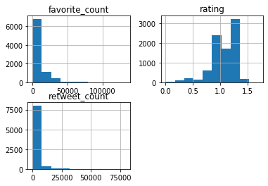

```python
# plot the histogram of numeric cols
df[['favorite_count','retweet_count','rating']].hist();
```

### Question:

- Tweet with more favorites get more retweet ?
- Do the tweets with many retweet or favorite_count get better rating ?
- Which channel attracts more users ?
- Is there relationship betwwen the source and n_reply, retweet_count, favourite or rating ?
- Which dog_type get the most favorite, retweet or rating ?
- Is there relationship between the posting time and n_reply, retweet_count, favourite or rating?
- Is there relationship between the tweet_id and retweet_count, favourite or rating?

```python
df.shape
```

```
(8580, 12)
```

> **Q1: Tweet with more favourites get more retweet ?**

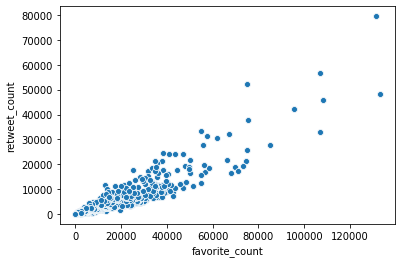

```python
sb.scatterplot(x="favorite_count", y="retweet_count", data=df)
```

> **Answer:** It seems the more they favor, the more they retweet

> **Q2: Do the tweets with many retweet or favorite_count get better rating**

[figure not shown]

```python
fig, axes = plt.subplots(1, 2, figsize = (10,4))
sb.scatterplot(x="favorite_count", y="rating", data=df, ax=axes[0], hue = 'favorite_count')
sb.scatterplot(x="retweet_count", y="rating", data=df,ax=axes[1])
axes[0].set_title('Rating by retweet')
axes[1].set_title('Rating by favorite');
```

```python
df.rating.corr(np.log(df.favorite_count))
```

```
0.4505471903585051
```

> **Answer:** It can be seen that the rating increase slightly by a log function of retweet count or favorite count

> **Q3:Which channel attracts more users ?**

```python
# Source and n_reply
source_with_reply = df.query('in_reply_to_status_id != "not_exist"')
source_with_reply.groupby('source').count()['tweet_id']
```

```
source
Twitter for iPhone    280
Name: tweet_id, dtype: int64
```

```python
source = df.source.value_counts()
source
```

```
Twitter for iPhone     8052
Vine - Make a Scene     364
Twitter Web Client      124
TweetDeck                40
Name: source, dtype: int64
```

> **Q4: Is there relationship between the source and n_reply, retweet_count, favourite or rating ?**

> **Answer:** Users use iphone plafform much more than others
> - Only the post from iphone receive reply

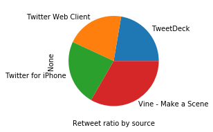

```python
ret = df.groupby('source')['retweet_count'].sum()
ret_by_source = (ret / source).astype(int)
ret_by_source.plot(kind='pie', figsize=(4,3))
plt.xlabel("Retweet ratio by source")
```

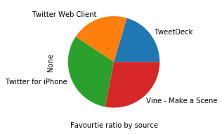

```python
# calculate the retweet rating by different sources
fav = df.groupby('source')['favorite_count'].sum()
fav_by_source = (fav / source).astype(int)
fav_by_source.plot(kind='pie', figsize=(4,3))
plt.xlabel("Favourtie ratio by source")
```

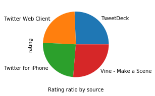

```python
# Source and rating
#plt.figure(figsize=(8,6))
rating = df.groupby('source')['rating'].mean()
rating.plot(kind='pie', figsize=(4,3))
plt.xlabel("Rating ratio by source")
```

> **Q5: Which dog_type get the most favorite, retweet or rating ?**

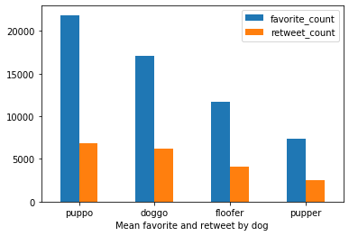

```python
dog = df.query("dog_type != 'not_exist'")
ax = dog.groupby('dog_type')['favorite_count','retweet_count'].mean().sort_values(by='favorite_count',ascending =False )
ax.plot(kind='bar')
plt.xticks(rotation='horizontal')
plt.xlabel("Mean favorite and retweet by dog")
```

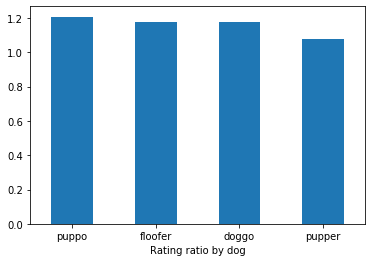

```python
ax = dog.groupby('dog_type')['rating'].mean().sort_values(ascending =False )
ax.plot(kind='bar')
plt.xticks(rotation='horizontal')
plt.xlabel("Rating ratio by dog")
```

> **Answer:** It's good when there are a significant difference in favorite and retweet by dog type but it doesn't effect the final rating from users

> **Q6: Is there relationship between date time and n_reply, retweet_count, favourite or rating?**

```python
df['created_at'] = pd.to_datetime(df['created_at'])
```

```python
type(df['created_at'][0])
```

```
pandas._libs.tslibs.timestamps.Timestamp
```

```python
date = df.created_at.dt.date
```

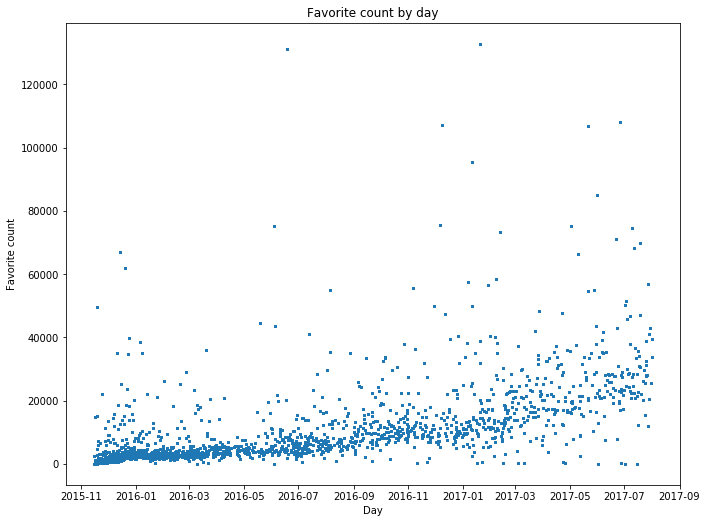

```python
plt.figure(1, figsize = (11, 8.5))
plt.plot(date,df.favorite_count,  marker = 'o', linestyle = '', ms = 2)
plt.title('Favorite count by day')
plt.xlabel('Day')
plt.ylabel('Favorite count')
plt.show()
```

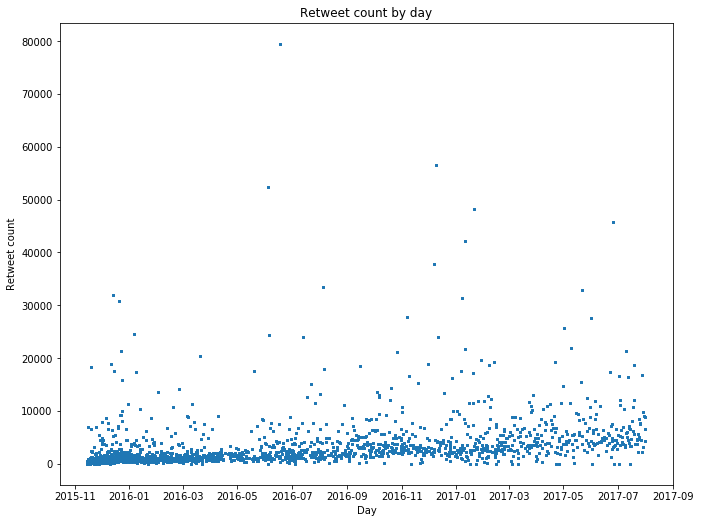

```python
plt.figure(1, figsize = (11, 8.5))
plt.plot(date,df.retweet_count,  marker = 'o', linestyle = '', ms = 2)
plt.title('Retweet count by day')
plt.xlabel('Day')
plt.ylabel('Retweet count')
plt.show()
```

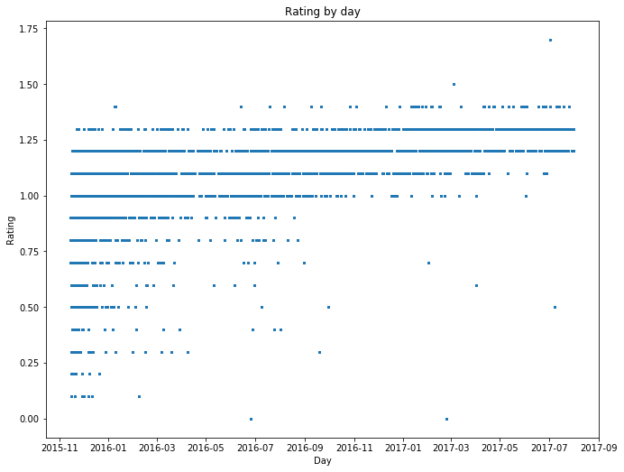

```python
plt.figure(1, figsize = (11, 8.5))
plt.plot(date,df.rating,  marker = 'o', linestyle = '', ms = 2)
plt.title('Rating by day')
plt.xlabel('Day')
plt.ylabel('Rating')
plt.show()
```